# Reproducible reports with R

Claudio Fronterrè

18 July 2018

# 1 Introduction

When we write a paper, or we produce slides for a conference or notes for a course we usually want to put together the output generated with R -a figure or the result of some statistical model- and some text that describes this ouput. A lot of time we end up copy and paste from our statistial software to our favourite text editor. However, this process is very inefficient and not reproducible.

R Markdown is an R package that allows you to integrate R code (and its ouput) with text to generate high quality reports in different formats (i.e. HTML, PDF, MS Word). The text is written using Markdown, a simple formatting syntax.

This is an introductory guide to the use of R Markdown especially for the production of reproducible articles. For a more thorough description of the features of R Markdown see http://rmarkdown.rstudio.com and [R Markdown: The Definitive Guide](https://bookdown.org/yihui/rmarkdown/). You may also find the following cheatsheet and reference guide really helpful [The R Markdown Cheatsheet](https://www.rstudio.com/wp-content/uploads/2016/03/rmarkdown-cheatsheet-2.0.pdf), [The R Markdown Reference Guide](https://www.rstudio.com/wp-content/uploads/2015/03/rmarkdown-reference.pdf)

There are a large number of tasks that you could do with R Markdown:

- Compile a single R Markdown document to a report in different formats, such as PDF, HTML, or Word.
- Create notebooks in which you can directly run code chunks interactively.
- Make slides for presentations (HTML5, LaTeX Beamer, or PowerPoint).
- Produce dashboards with flexible, interactive, and attractive layouts.
- Build interactive applications based on [Shiny](https://shiny.rstudio.com/).
- Write journal articles.
- Author books of multiple chapters.
- Generate websites and blogs.

## 1.1 Installation

It is strongly reccomended to use [RStudio](https://www.rstudio.com/), even if it is not required, because it makes it easier to work with R Markdown. Then install the `rmarkdown` package in R:

```r
install.packages("rmarkdown")
```

If you want to generate PDF output, you will need to install LaTeX. For R users who have not installed LaTeX before, a quick solution is to install [TinyTeX](https://yihui.name/tinytex/):

```r
install.packages("tinytex")
tinytex::install_tinytex()
```

## 1.2 Get Started

In RStudio, open a new R Markdown file.

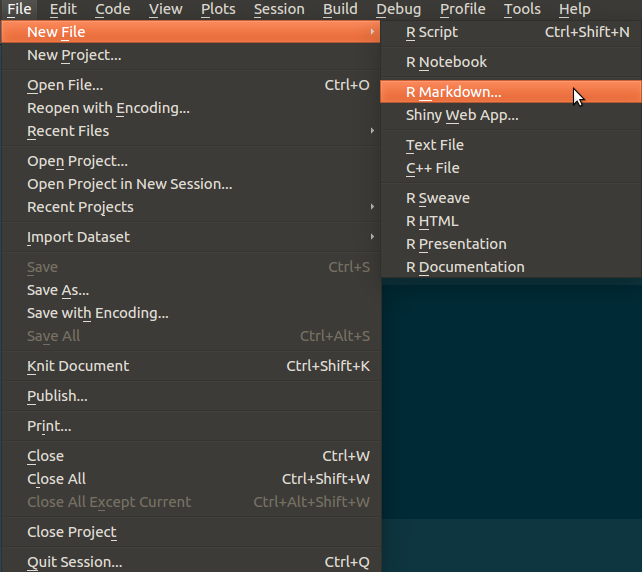

In the dialog box that appears, select the output format and write the Title and Author. These last two sections can be stated also later. If you have installed some specific packages that includes other rmarkdown templates you will fin them in the **From Template** tab.

[figure not shown]

An Rmd file appears with front matter and some sample text. You can know start to write some text and add chunks of R code. The figure below shows the standard format and the 3 main parts of an Rmd file:

- A YAML header where you can specify general formatting options for the entire document.
- R code chunks, these contain your R code and they have an header where it is possible to specify a series of option such as weather to show the code or not, how to treat figures produced by your output and so on.
- Text mixed with simple text formatting.

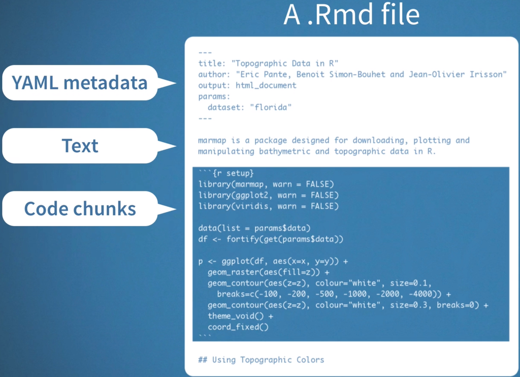

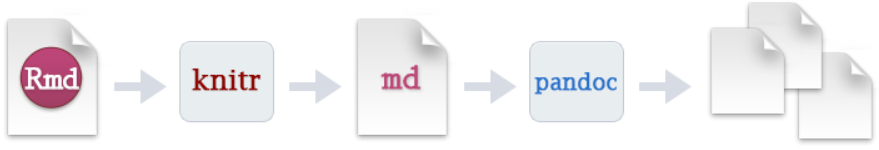

R Markdown feeds the .Rmd file to [knitr](https://yihui.name/knitr/) which executes all of the code chunks and creates a new markdown (.md) document which includes the code and it’s output. Then markdown file generated by knitr is then processed by [pandoc](http://pandoc.org/) which is responsible for creating the finished format.

# 2 Including R code

All the R code goes in what is called a *chunk*. You can quickly insert chunks with the keyboard shortcut **Ctrl + Alt + I** or with the Inser chunk button in the editor toolbar.

## 2.1 Chunk options

In the header of an R chunk it is possible to specify [knitr options](https://yihui.name/knitr/options/) to customise the your output. This can be specified separately for each R chunk or you could set global options that apply to every chunk in your file calling `knitr::opts_chunk$set` in a code chunk as in the example below.

This makes it easy to update the report

````markdown
Thi is a code chunk where I set up global options:

```{r}
knitr::opts_chunk$set(echo = TRUE)
```
````

See the [R Markdown Reference Guide](https://www.rstudio.com/wp-content/uploads/2015/03/rmarkdown-reference.pdf) for a complete list of knitr chunk options.

## 2.2 Inline R code

Code results can be inserted directly into the text of a .Rmd file by enclosing the code with `` `r ` ``.

# 3 Including Figures

By default, figures produced by R code will be placed immediately after the code chunk they were generated from. For example:

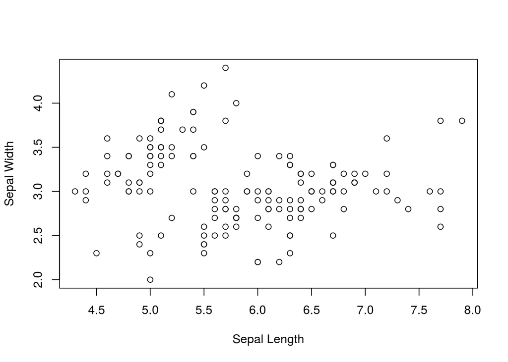

```r
plot(iris$Sepal.Length, iris$Sepal.Width, xlab = "Sepal Length", ylab = "Sepal Width")
```

You can provide a figure caption using `fig.cap` in the chunk options. See the example below.

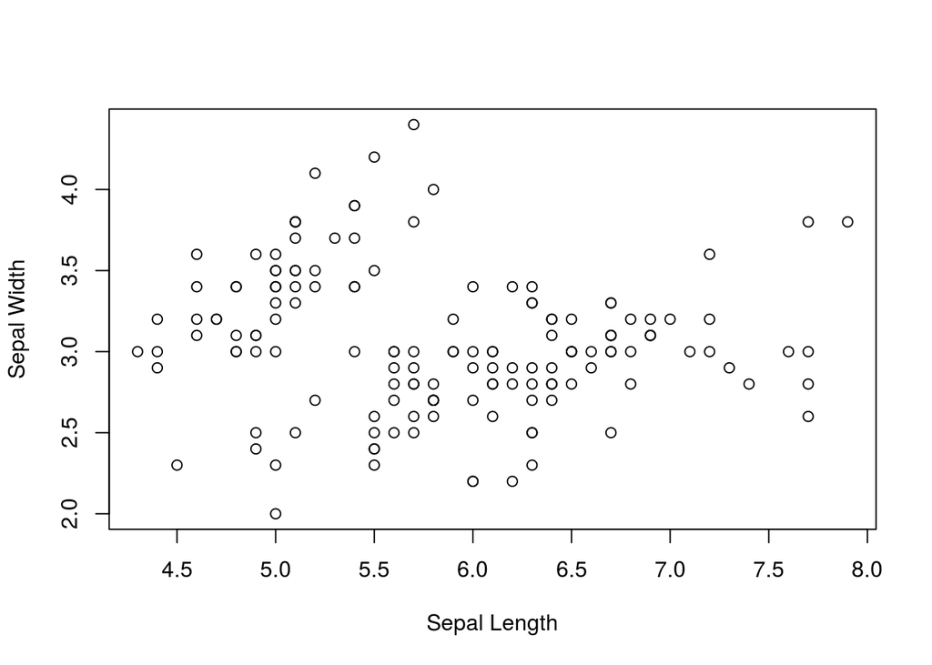

My scatterplot

```r
plot(iris$Sepal.Length, iris$Sepal.Width, xlab = "Sepal Length", ylab = "Sepal Width")
```

In the case of PDF output, such figures will be automatically numbered. If you also want to number figures in other formats (such as HTML), please see the [`bookdown`](https://bookdown.org/yihui/bookdown/) package.

To place multiple figures side-by-side from the same code chunk, you can use the `fig.hold='hold'` option along with the `out.width` option. The figure below shows an example with two plots, each with a width of `50%`.

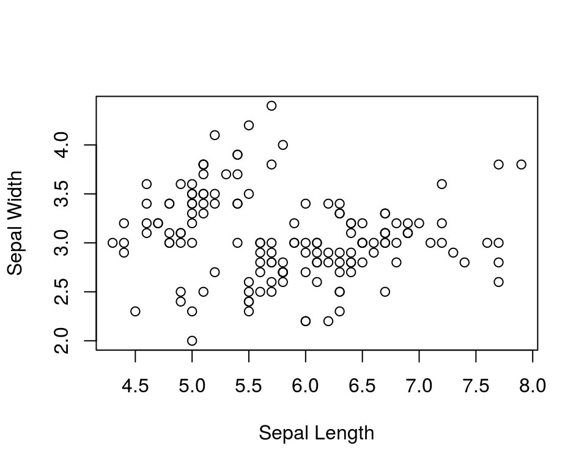

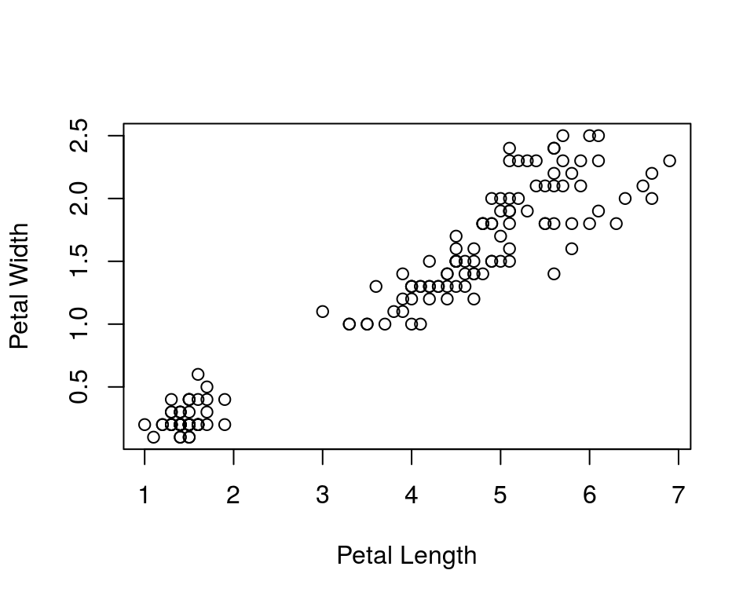

Two plots side-by-side.

```r
plot(iris$Sepal.Length, iris$Sepal.Width, xlab = "Sepal Length", ylab = "Sepal Width")
plot(iris$Petal.Length, iris$Petal.Width, xlab = "Petal Length", ylab = "Petal Width")
```

If you want to include a graphic that is not generated from R code, you may use the `knitr::include_graphics()` function, which gives you more control over the attributes of the image than the Markdown syntax of `![alt text or image title](path/to/image)` (e.g., you can specify the image width via `out.width`).